# Practical Lab 5 - Multivariate Regression, Non-Parametric Models and Cross-Validation

## Problem Statement

The objective is to develop a multivariate polynomial regression, decision tree and KNN models, compare the models and find the best model that, in considering two features such as the body mass index (BMI),LTG in the dataset, can effectively forecast the risk of diabetes progression. This will assist doctors in identifying people who are at danger by serving as a screening tool.

## Data Collection

Diabetes dataset is a small standard dataset available in scikit-learn. Diabetes dataset is collected by taking ten baseline features such as Age, Sex, Body Mass Index, average blood pressure, six blood serum measurements such as total serum cholestrol, LDL, HDL, Total cholestrol/HDL, LTG, blood sugar level from 442 patients and target which is a measure of diabetes progession one year after baseline. The 10 feature variables have been mean centered and scaled by the standard deviation times the square root of number of samples.

## Importing Dataset

We will be importing the non-scaled dataset

```python
import pandas as pd
import numpy as np
import seaborn as sns
from sklearn.linear_model import LinearRegression
from sklearn.metrics import mean_squared_error, mean_absolute_error,r2_score,mean_absolute_percentage_error
from sklearn import datasets
import matplotlib.pyplot as plt
from sklearn.model_selection import train_test_split
from sklearn.preprocessing import PolynomialFeatures
from sklearn import tree
from sklearn.pipeline import make_pipeline
from sklearn.neighbors import KNeighborsClassifier
from sklearn.model_selection import cross_validate
import warnings
warnings.filterwarnings("ignore")
```

```python
diabetes_dataset = datasets.load_diabetes(as_frame = True,scaled=False)
df_diabetes_data = diabetes_dataset['frame']
df_diabetes_data.head(10)
```

|  | age | sex | bmi | bp | s1 | s2 | s3 | s4 | s5 | s6 | target |
| --- | --- | --- | --- | --- | --- | --- | --- | --- | --- | --- | --- |
| 0 | 59.0 | 2.0 | 32.1 | 101.0 | 157.0 | 93.2 | 38.0 | 4.00 | 4.8598 | 87.0 | 151.0 |
| 1 | 48.0 | 1.0 | 21.6 | 87.0 | 183.0 | 103.2 | 70.0 | 3.00 | 3.8918 | 69.0 | 75.0 |
| 2 | 72.0 | 2.0 | 30.5 | 93.0 | 156.0 | 93.6 | 41.0 | 4.00 | 4.6728 | 85.0 | 141.0 |
| 3 | 24.0 | 1.0 | 25.3 | 84.0 | 198.0 | 131.4 | 40.0 | 5.00 | 4.8903 | 89.0 | 206.0 |
| 4 | 50.0 | 1.0 | 23.0 | 101.0 | 192.0 | 125.4 | 52.0 | 4.00 | 4.2905 | 80.0 | 135.0 |
| 5 | 23.0 | 1.0 | 22.6 | 89.0 | 139.0 | 64.8 | 61.0 | 2.00 | 4.1897 | 68.0 | 97.0 |
| 6 | 36.0 | 2.0 | 22.0 | 90.0 | 160.0 | 99.6 | 50.0 | 3.00 | 3.9512 | 82.0 | 138.0 |
| 7 | 66.0 | 2.0 | 26.2 | 114.0 | 255.0 | 185.0 | 56.0 | 4.55 | 4.2485 | 92.0 | 63.0 |
| 8 | 60.0 | 2.0 | 32.1 | 83.0 | 179.0 | 119.4 | 42.0 | 4.00 | 4.4773 | 94.0 | 110.0 |
| 9 | 29.0 | 1.0 | 30.0 | 85.0 | 180.0 | 93.4 | 43.0 | 4.00 | 5.3845 | 88.0 | 310.0 |

## Exploratory Data Analysis

### Statistical Analysis

The sex variable contains two values 1 and 2. We assume 1 represents Male and 2 represents Female. We have added a new column called Gender in dataframe to hold the labels. The table describes the data present.

```python
sex_labels = {1: 'Male', 2: 'Female'}
gender =  [sex_labels[val] for val in df_diabetes_data['sex']]
df_diabetes_data['Gender'] = gender
print(df_diabetes_data.head(10))
df_diabetes_data.describe()
```

```
    age  sex   bmi     bp     s1     s2    s3    s4      s5    s6  target
0  59.0  2.0  32.1  101.0  157.0   93.2  38.0  4.00  4.8598  87.0   151.0  \
1  48.0  1.0  21.6   87.0  183.0  103.2  70.0  3.00  3.8918  69.0    75.0
2  72.0  2.0  30.5   93.0  156.0   93.6  41.0  4.00  4.6728  85.0   141.0
3  24.0  1.0  25.3   84.0  198.0  131.4  40.0  5.00  4.8903  89.0   206.0
4  50.0  1.0  23.0  101.0  192.0  125.4  52.0  4.00  4.2905  80.0   135.0
5  23.0  1.0  22.6   89.0  139.0   64.8  61.0  2.00  4.1897  68.0    97.0
6  36.0  2.0  22.0   90.0  160.0   99.6  50.0  3.00  3.9512  82.0   138.0
7  66.0  2.0  26.2  114.0  255.0  185.0  56.0  4.55  4.2485  92.0    63.0
8  60.0  2.0  32.1   83.0  179.0  119.4  42.0  4.00  4.4773  94.0   110.0
9  29.0  1.0  30.0   85.0  180.0   93.4  43.0  4.00  5.3845  88.0   310.0

   Gender
0  Female
1    Male
2  Female
3    Male
4    Male
5    Male
6  Female
7  Female
8  Female
9    Male
```

|  | age | sex | bmi | bp | s1 | s2 | s3 | s4 | s5 | s6 | target |
| --- | --- | --- | --- | --- | --- | --- | --- | --- | --- | --- | --- |
| count | 442.000000 | 442.000000 | 442.000000 | 442.000000 | 442.000000 | 442.000000 | 442.000000 | 442.000000 | 442.000000 | 442.000000 | 442.000000 |
| mean | 48.518100 | 1.468326 | 26.375792 | 94.647014 | 189.140271 | 115.439140 | 49.788462 | 4.070249 | 4.641411 | 91.260181 | 152.133484 |
| std | 13.109028 | 0.499561 | 4.418122 | 13.831283 | 34.608052 | 30.413081 | 12.934202 | 1.290450 | 0.522391 | 11.496335 | 77.093005 |
| min | 19.000000 | 1.000000 | 18.000000 | 62.000000 | 97.000000 | 41.600000 | 22.000000 | 2.000000 | 3.258100 | 58.000000 | 25.000000 |
| 25% | 38.250000 | 1.000000 | 23.200000 | 84.000000 | 164.250000 | 96.050000 | 40.250000 | 3.000000 | 4.276700 | 83.250000 | 87.000000 |
| 50% | 50.000000 | 1.000000 | 25.700000 | 93.000000 | 186.000000 | 113.000000 | 48.000000 | 4.000000 | 4.620050 | 91.000000 | 140.500000 |
| 75% | 59.000000 | 2.000000 | 29.275000 | 105.000000 | 209.750000 | 134.500000 | 57.750000 | 5.000000 | 4.997200 | 98.000000 | 211.500000 |
| max | 79.000000 | 2.000000 | 42.200000 | 133.000000 | 301.000000 | 242.400000 | 99.000000 | 9.090000 | 6.107000 | 124.000000 | 346.000000 |

### Histogram for Body Mass Index

The Histogram is plotted by taking BMI on x axis and Frequency on y axis. From the graph it can be inferred that around 183 patients falls within healthy weight range, 148 patients are overweight and remaining 111 patients are obese.

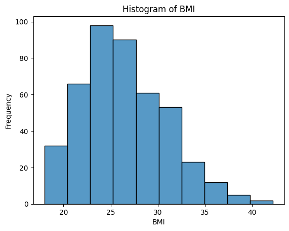

```python
sns.histplot(data = df_diabetes_data, x = "bmi",bins = 10)
plt.xlabel('BMI')
plt.ylabel('Frequency')
plt.title('Histogram of BMI')
plt.show()
```

### Scatterplot showing the relationship between Age and BMI

Scatterplot is plotted by taking Age on x axis and BMI on y axis. From the graph it is found that mostly patients with age between 20 and 30 are maintaing healthy weight. Some people in the age range of 40 and 50 are overweight or obese.

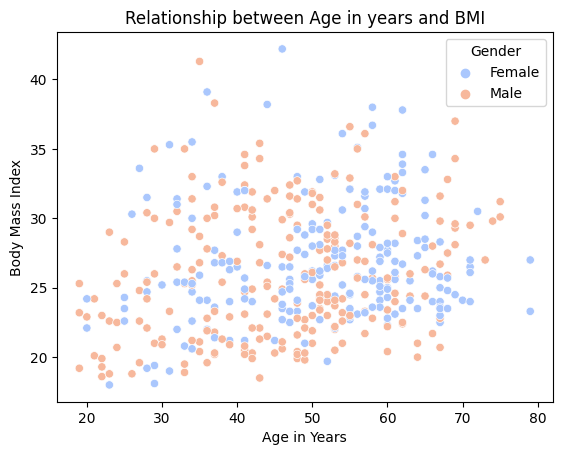

```python
sns.scatterplot(data = df_diabetes_data, x = "age", y="bmi",hue = "Gender",palette="coolwarm")
plt.title("Relationship between Age in years and BMI")
plt.xlabel("Age in Years")
plt.ylabel("Body Mass Index")
plt.show()
```

### Correlation Matrix

Correlation matrix displays the correlation coefficients between two variables. Heat map is plotted by taking correlation matrix values of 10 feature variables and target. From the correlation matrix it can be inferred that correlation coefficient of BMI and target are closely related. Similarly the features S1 (Total serum cholestrol) and S2 (LDL) are highly correlated to each other. Features S3 (HDL) and S4(Total Cholestrol) are negatively correlated having a negative correlation coefficient of -0.74.

```
             age       sex       bmi        bp        s1        s2        s3
age     1.000000  0.173737  0.185085  0.335428  0.260061  0.219243 -0.075181  \
sex     0.173737  1.000000  0.088161  0.241010  0.035277  0.142637 -0.379090
bmi     0.185085  0.088161  1.000000  0.395411  0.249777  0.261170 -0.366811
bp      0.335428  0.241010  0.395411  1.000000  0.242464  0.185548 -0.178762
s1      0.260061  0.035277  0.249777  0.242464  1.000000  0.896663  0.051519
s2      0.219243  0.142637  0.261170  0.185548  0.896663  1.000000 -0.196455
s3     -0.075181 -0.379090 -0.366811 -0.178762  0.051519 -0.196455  1.000000
s4      0.203841  0.332115  0.413807  0.257650  0.542207  0.659817 -0.738493
s5      0.270774  0.149916  0.446157  0.393480  0.515503  0.318357 -0.398577
s6      0.301731  0.208133  0.388680  0.390430  0.325717  0.290600 -0.273697
target  0.187889  0.043062  0.586450  0.441482  0.212022  0.174054 -0.394789

              s4        s5        s6    target
age     0.203841  0.270774  0.301731  0.187889
sex     0.332115  0.149916  0.208133  0.043062
bmi     0.413807  0.446157  0.388680  0.586450
bp      0.257650  0.393480  0.390430  0.441482
s1      0.542207  0.515503  0.325717  0.212022
s2      0.659817  0.318357  0.290600  0.174054
s3     -0.738493 -0.398577 -0.273697 -0.394789
s4      1.000000  0.617859  0.417212  0.430453
s5      0.617859  1.000000  0.464669  0.565883
s6      0.417212  0.464669  1.000000  0.382483
target  0.430453  0.565883  0.382483  1.000000
```

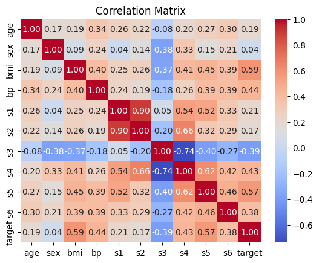

```python
df_diabetes_data = df_diabetes_data.drop(columns = ['Gender'])
corr_matrix = df_diabetes_data.corr()
print(corr_matrix)
sns.heatmap(corr_matrix, annot=True, cmap='coolwarm', fmt=".2f", annot_kws={"size": 10})
plt.title('Correlation Matrix')
plt.show()
```

## Data Cleaning

I think there is no need for Data cleaning as the dataset does not contain any missing values and there is not such outliers. Instead of considering only one feature, we are going to consider two features such as BMI and LTG because it is closely correlated to the target variable and has a correlation coefficient in the range of 0.59 and 0.57 respectively.

## Splitting the dataset into training and test dataset

```python
# splitting the dataset into training(80%) and testing(20%) dataset
X_train,X_test,y_train,y_test = train_test_split(df_diabetes_data[["bmi","s5"]], df_diabetes_data[["target"]], test_size=0.2, random_state=0)
```

## Model Training

We have performed cross validation on 2 polynomial models of degree 1 and 2, decision trees of max depth 2 and 3, KNN models considering 5 and 6 nearest neighbors.

```python
models = []
degrees = [1,2]
max_depth = [2,3]
n_neighbors = [5,6]
cross_val_scores = []
model_names = ["Polynomial Model Degree 1","Polynomial Model Degree 2","Decision Tree Depth 2","Decision Tree Depth 3","KNN - 5 neighbors","KNN - 6 neighbors"]

# Multivariate Polynomial models of degree 1 and 2
for deg in degrees:
    model = make_pipeline(PolynomialFeatures(deg), LinearRegression())
    models.append(model)
# Decision Trees of depth 2 and 3
for depth in max_depth:
    model = tree.DecisionTreeRegressor(max_depth=depth)
    models.append(model)
# KNN of neighbors 5 and 6
for n in n_neighbors:
    model = KNeighborsClassifier(n_neighbors=n)
    models.append(model)

for index,model in enumerate(models):
    cross_val_results = cross_validate(model,X_train,y_train,cv = 5, scoring= ('r2', 'neg_mean_absolute_error','neg_mean_absolute_percentage_error'))
    Mean_R2 = np.mean(cross_val_results['test_r2'])
    Mean_MAE = np.mean(np.abs(cross_val_results['test_neg_mean_absolute_error']))
    SD_R2 = np.std(cross_val_results['test_r2'])
    SD_MAE = np.std(np.abs(cross_val_results['test_neg_mean_absolute_error']))
    Mean_MAPE = np.mean(np.abs(cross_val_results['test_neg_mean_absolute_percentage_error']))
    SD_MAPE = np.std(np.abs(cross_val_results['test_neg_mean_absolute_percentage_error']))
    cross_val_scores.append([model_names[index],Mean_R2,SD_R2,Mean_MAE,SD_MAE,Mean_MAPE,SD_MAPE])
```

## Cross Validation Results

The below table shows the cross validation results such as R-squared, (Mean absolute Error) MAE, (Mean Absolute percentage error) MAPE for 5 folds on all the six models

```python
metrics = pd.DataFrame(cross_val_scores, columns=["Model Name","Mean R-squared value","SD R-squared value","Mean MAE","SD MAE","Mean MAPE","SD MAPE"])
metrics.head(10)
```

|  | Model Name | Mean R-squared value | SD R-squared value | Mean MAE | SD MAE | Mean MAPE | SD MAPE |
| --- | --- | --- | --- | --- | --- | --- | --- |
| 0 | Polynomial Model Degree 1 | 0.484827 | 0.050244 | 46.674431 | 1.818483 | 0.421279 | 0.042865 |
| 1 | Polynomial Model Degree 2 | 0.480806 | 0.039512 | 46.857324 | 1.861676 | 0.418333 | 0.036035 |
| 2 | Decision Tree Depth 2 | 0.429181 | 0.029754 | 47.260700 | 1.767926 | 0.424719 | 0.024913 |
| 3 | Decision Tree Depth 3 | 0.461225 | 0.042797 | 45.737001 | 2.105737 | 0.407030 | 0.026495 |
| 4 | KNN - 5 neighbors | -0.237259 | 0.132720 | 67.879517 | 7.909136 | 0.421222 | 0.033991 |
| 5 | KNN - 6 neighbors | -0.300365 | 0.143911 | 69.891992 | 8.068892 | 0.432330 | 0.027381 |

## Best Model Identification

### Test data run on best model

```python
# Multivariate polynomial regression model of Degree 1 is best model when compared to Decision trees and KNN
model = models[0]
model.fit(X_train,y_train)
test_r_square = r2_score(y_test,model.predict(X_test))
test_MAPE = mean_absolute_percentage_error(y_test,model.predict(X_test))
test_MAE = mean_absolute_error(y_test,model.predict(X_test))
print(f'R-squared value of Polynomial Regression of Degree 1 is {test_r_square:.2f}')
print(f'Mean Absolute Percentage error of Polynomial Regression of Degree 1 is {test_MAPE:.2f}')
print(f'Mean Absolute Error of Polynomial Regression of Degree 1 is {test_MAE:.2f}')
```

```
R-squared value of Polynomial Regression of Degree 1 is 0.28
Mean Absolute Percentage error of Polynomial Regression of Degree 1 is 0.40
Mean Absolute Error of Polynomial Regression of Degree 1 is 47.98
```

### Plotting graph for the best model

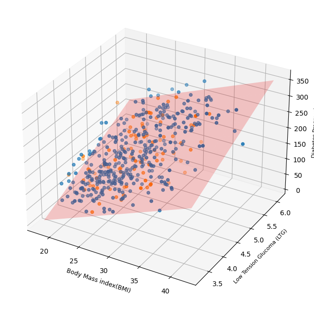

```python
X1 = df_diabetes_data[["bmi"]].values
X2 = df_diabetes_data[["s5"]].values
#X3 = df_diabetes_data[["s6"]].values
x1_cont = np.linspace(min(X1), max(X1), num=10)
x2_cont = np.linspace(min(X2), max(X2), num=10)
#x3_cont = np.linspace(min(X3), max(X3), num=10)
x1_mesh, x2_mesh = np.meshgrid(x1_cont, x2_cont)
X_mesh = np.array([x1_mesh.flatten(), x2_mesh.flatten()]).T
y_pred_mesh = model.predict(X_mesh)
y_pred = y_pred_mesh.reshape(x1_mesh.shape)
# Plotting 3D plot
fig = plt.figure(figsize=(10,8))
ax = fig.add_subplot(111, projection='3d')
ax.scatter(X_train["bmi"],X_train["s5"],y_train, label='Training Data')
ax.scatter(X_test["bmi"],X_test["s5"], y_test, label='Testing Data')
ax.plot_surface(x1_mesh, x2_mesh, y_pred, color='red', alpha=0.2)
ax.set_xlabel('Body Mass index(BMI)', fontsize=9)
ax.set_ylabel('Low Tension Glucoma (LTG)', fontsize=8)
ax.set_zlabel('Diabetes Progression', fontsize=8)
plt.show()
```

## Conclusion

### Model Limitiations:

Polynomial regression models are capable of identifying the non-linear relationships but polynomial regression model of degree 1 assumes that linear relationship exits between dependent and independent variable but which is not the case with diabetes dataset. I think the model is facing underfitting issue.